# Analizando datos con R

Octubre 2014

## Sobre mi:

[figure not shown]

[r-es.org](http://r-es.org/)  
[madrid.r-es.org](http://madrid.r-es.org/)

[figure not shown]

[www.conento.com](http://www.conento.com/)

## ¿Qué es R?

R es un lenguaje y entorno de programación para el análisis estadístico y gráfico.

### http://www.r-project.org/

## ¿Por qué R?

- Gratuito y abierto.
- Disponible para todas las plataformas.
- Flexible.
- Actualizado.
- Última tecnología.

## ¿Por donde empezar?

- [R y alrededores…](http://prezi.com/-3jqhcpmyqpq/r-y-alrededores-web-semantica-2013-sep/) (Carlos Ortega).
- [R desde el principio: Curso cero de R](http://r-es.org/Programa+de+las+VI+Jornadas) (Emilio López Cano).

## Ejemplo práctico: ¡Viva el vino!

Usaremos los datos de vinos disponibles en [www.verema.es](http://www.verema.com/vinos/portada):

[figure not shown]

[figure not shown]

## Web Scraping

Descargamos los datos haciendo uso de los paquetes `XLM`, `RCurl` y `RSelenium`.

[video not shown]

## Los datos

| Vino | Añada | Bodega | Puntos | Comentarios | Precio | DO |
| --- | --- | --- | --- | --- | --- | --- |
| Torelló Brut Reserva | 2008 | Torelló Cava | 8.7 | 1 | 10-20 | D.O. Cava |
| Protos selección | 2005 | Bodegas Protos | 8.4 | 1 | 20-30 | D.O. Ribera del Duero |
| Pesquera Magnum Reserva | 2007 | Alejandro Fernández - Tinto Pesquera | NA | 0 | 50-100 | D.O. Ribera del Duero |
| Chafandin Tempranillo | 2004 | Bodegas y Viñedos del Jaro (Compañía de Viñedos Iberian) | NA | 0 | 30-50 | D.O. Ribera del Duero |
| Montesierra Crianza Réhoboam 2004 | 2004 | Pirineos | NA | 0 | 30-50 | D.O. Somontano |
| Protos rosado | 2008 | Bodegas Protos | 7.9 | 1 | 5-10 | D.O. Ribera del Duero |
| Las Alcaydias Selección Barricas | 2002 | Viñedos Heretat de Cesilia | 8.0 | 12 | 5-10 | D.O. Alicante |
| Vinya Orlina Blanco | 2012 | Celler Cooperatiu D´Espolla | NA | 0 | 0-5 | D.O. Empordà |

**Un total de 18.037 registros.**

## Relación precio y puntuación

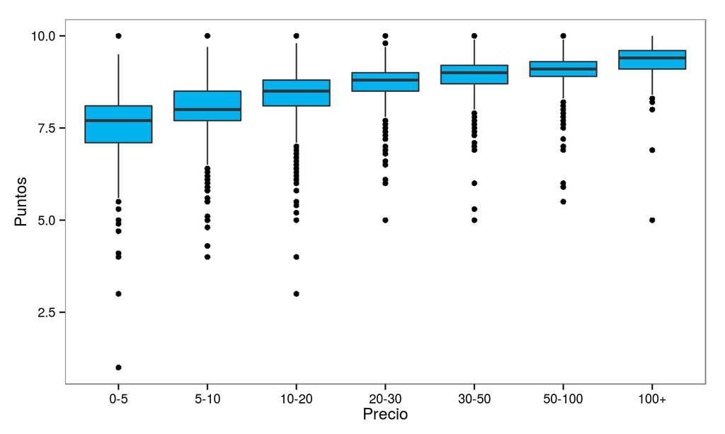

```r
ggplot(todo[!is.na(todo$Precio),],aes(x=Precio,y=Puntos))+geom_boxplot(fill="deepskyblue2")
```

## Relación añada y puntuación

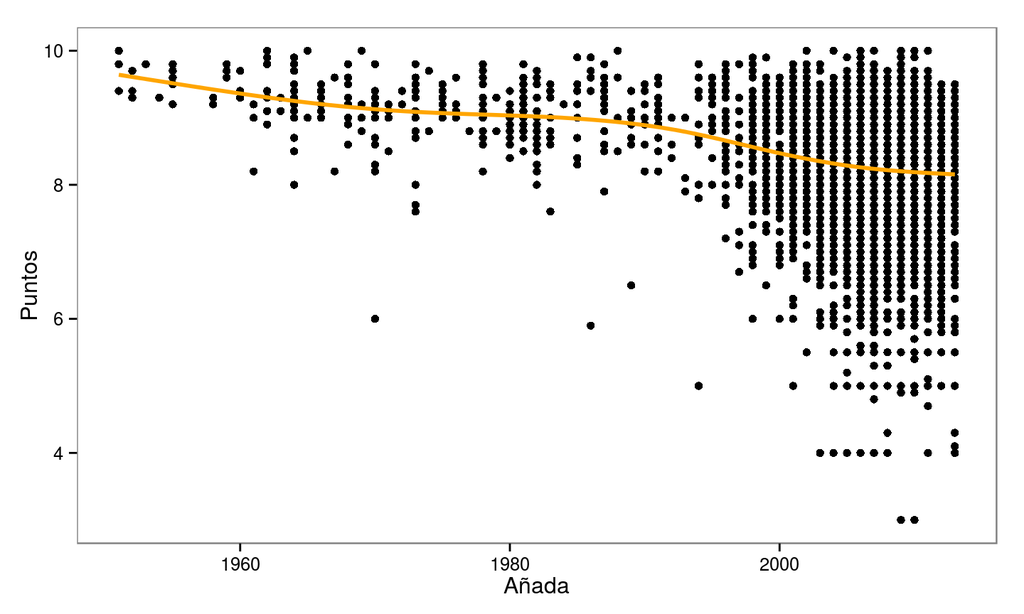

```r
ggplot(todo[todo$Añada>=1950,],aes(x=Añada,y=Puntos))+geom_point()+
  geom_smooth(se=FALSE,lwd=1,col="orange")
```

## Mapas

1. Descargamos el mapa vectorial de las Denominaciones de Origen del [Ministerio de Agricultura, Alimentación y Medio Ambiente](http://www.magrama.gob.es/es/cartografia-y-sig/ide/descargas/alimentacion/calidad-diferenciada.aspx).
2. Agregamos los datos de Verema:

```r
todo[,list(.N,Puntos=mean(Puntos,na.rm = T),Precio=mean(Precio2)),by=DO_id]
```

```
##                  DO_id   N   Puntos    Precio
## 1:          binissalem  52 8.035135 14.375000
## 2: campo de la guardia   4 8.075000 11.250000
## 3:          pago ayles  13 8.338462  6.346154
## 4: pago los balagueses   8 8.614286 15.000000
## 5:           somontano 446 7.993939 10.829596
## 6:     valle de guimar  10 8.350000 13.750000
## 7:              alella  82 8.165000 13.445122
## 8:            cataluna 197 7.904196  9.213198
```

3. Cruzamos ambas tablas por D.O.

## Mapas

Usando el paquete `ggmap`, descargamos un mapa base y pintamos encima:

[figure not shown]

[interactive chart not shown]

```r
ggmap(map,extent = "device")+
  geom_polygon(aes(x=long,y=lat,group=group,fill=Puntos),data=ddoo_df,col="white",alpha = .4, size = .2)
```

## Machine Learning

[figure not shown]

http://archive.ics.uci.edu/ml/datasets/Wine+Quality

Paquete [`caret`](http://caret.r-forge.r-project.org/)

Enlaces de interés:

- http://www-bcf.usc.edu/~gareth/ISL/
- http://statweb.stanford.edu/~tibs/ElemStatLearn/
- http://appliedpredictivemodeling.com/

## Los datos

Se dispone de 11 medidas químicas para 6.497 "Vinho verde" (Portugal).

```r
str(xx.all)
```

```
## 'data.frame':    6497 obs. of  13 variables:
##  $ fixed.acidity       : num  7.4 7.8 7.8 11.2 7.4 7.4 7.9 7.3 7.8 7.5 ...
##  $ volatile.acidity    : num  0.7 0.88 0.76 0.28 0.7 0.66 0.6 0.65 0.58 0.5 ...
##  $ citric.acid         : num  0 0 0.04 0.56 0 0 0.06 0 0.02 0.36 ...
##  $ residual.sugar      : num  1.9 2.6 2.3 1.9 1.9 1.8 1.6 1.2 2 6.1 ...
##  $ chlorides           : num  0.076 0.098 0.092 0.075 0.076 0.075 0.069 0.065 0.073 0.071 ...
##  $ free.sulfur.dioxide : num  11 25 15 17 11 13 15 15 9 17 ...
##  $ total.sulfur.dioxide: num  34 67 54 60 34 40 59 21 18 102 ...
##  $ density             : num  0.998 0.997 0.997 0.998 0.998 ...
##  $ pH                  : num  3.51 3.2 3.26 3.16 3.51 3.51 3.3 3.39 3.36 3.35 ...
##  $ sulphates           : num  0.56 0.68 0.65 0.58 0.56 0.56 0.46 0.47 0.57 0.8 ...
##  $ alcohol             : num  9.4 9.8 9.8 9.8 9.4 9.4 9.4 10 9.5 10.5 ...
##  $ quality             : int  5 5 5 6 5 5 5 7 7 5 ...
##  $ tipo                : Factor w/ 2 levels "Blanco","Tinto": 2 2 2 2 2 2 2 2 2 2 ...
```

## Gráfico de correlaciones

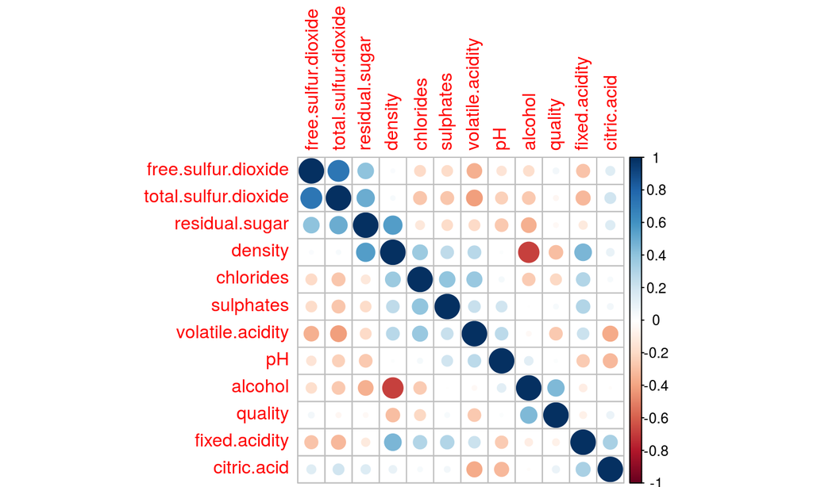

```r
corrplot(cor(xx.all[,-indY]),order="hclust",bg = "transparent")
```

## ¿Tinto o blanco?

Queremos predecir de manera automática si un vino es tinto o blanco.

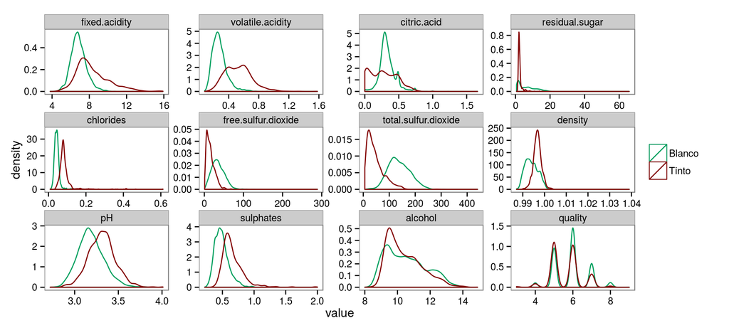

```r
ggplot(melt(xx.all,id.vars = "tipo"),aes(x=value,col=tipo))+facet_wrap(~variable,scales = "free")+
  geom_density()+scale_color_manual(values=c("#009f5d","#820000"))
```

## ¿Tinto o blanco?

Realizamos el aprendizaje usando el algoritmo [**Random Forest**](http://es.wikipedia.org/wiki/Random_forest). Consiguiendo resultados muy buenos:

```r
confusionMatrix(pred.test.class,xx.test$tipo)
```

```
Confusion Matrix and Statistics

          Reference
Prediction Blanco Tinto
    Blanco    978     2
    Tinto       1   317

               Accuracy : 0.9977
```

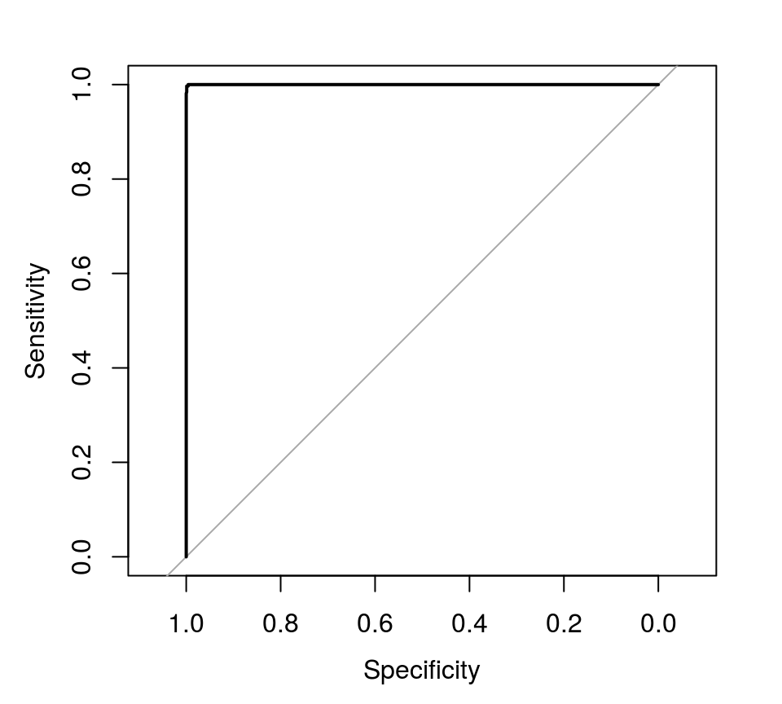

```
##
## Call:
## roc.default(response = xx.test$tipo, predictor = pred.test.prob[,     2], plot = T)
##
## Data: pred.test.prob[, 2] in 979 controls (xx.test$tipo Blanco) < 319 cases (xx.test$tipo Tinto).
## Area under the curve: 1
```

```r
roc(xx.test$tipo,pred.test.prob[, 2],plot=T)
```

## ¿Tinto o blanco?

También podemos observar las variables más importantes en el modelo:

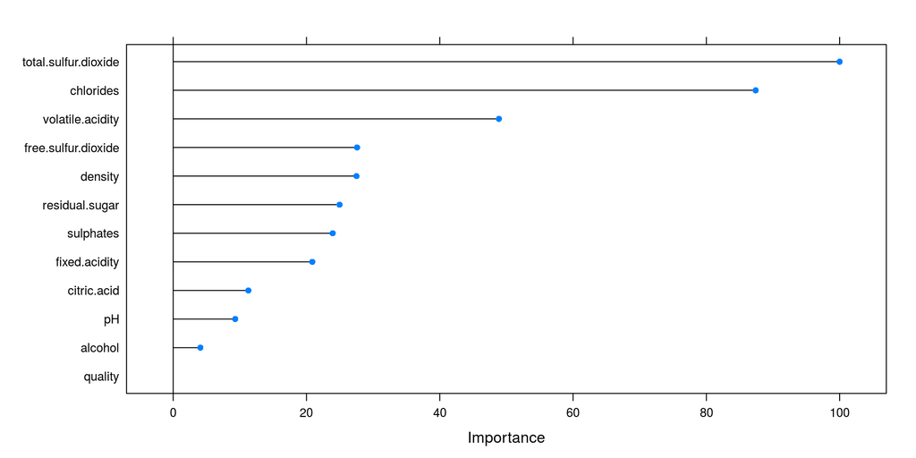

## ¿Calidad?

Vamos a intentar predecir la variable `quality` usando [**Support Vector Machine**](http://es.wikipedia.org/wiki/M%C3%A1quinas_de_vectores_de_soporte).

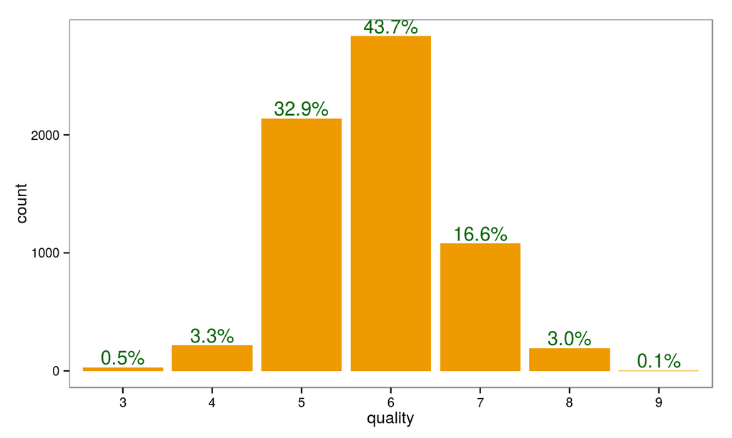

```r
ggplot(xx.all,aes(x=quality))+geom_bar(fill="orange2")+geom_text(aes(y = (..count..),
  label=scales::percent((..count..)/sum(..count..))),stat="bin",colour="darkgreen",vjust=-0.2)
```

## ¿Calidad?

Lanzamos el modelo:

```r
svm.fit = train ( xx.train[ , -indY ] , xx.train$quality ,
                  method = "svmRadial",
                  trControl = cv.ctrl,
                  tuneGrid = svmGrid
                  )
```

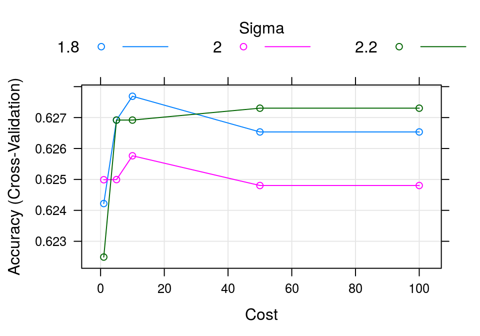

```
Confusion Matrix and Statistics

          Reference
Prediction   3   4   5   6   7   8   9
         3   0   0   0   0   0   0   0
         4   0   4   4   1   0   0   0
         5   0   9 297  80  12   2   0
         6   6  30 124 457  93  19   1
         7   0   0   2  28 110   8   0
         8   0   0   0   1   0   9   0
         9   0   0   0   0   0   0   0

Overall Statistics

               Accuracy : 0.6762
```

## !Gracias!

Esta presentación: http://jayusor.github.io/openanalytics_2014  
Códigos empleados: https://github.com/jayusor/openanalytics_2014